# Coronavirus Exploratory Data Analysis Report

Gagandeep Samra

3/22/2021

## Introduction

Coronavirus is an infectious disease that began in 2019. It can spread by having close contact with the person who has the symptom through the respiratory droplet. According to the CDC website, the symptoms are fever, cough, tiredness, shortness of breath, fatigue, headaches, etc. Some ways to prevent getting the Coronvirus are wearing a mask to cover the mouth and nose when going outside and be 6 feet apart from other people. Another thing to avoid large gatherings or crowds. Also, people can wash their hands with soap and water or use hand sanitizer. According to the Worldometer website, the current number of cases worldwide is 123,409,813, and the current deaths are 2,721,187.

## Set Up Libraries

In this step, I install the packages needed to carry out my analysis.

```r
library(ggplot2)
library(dplyr)
library(readxl)
```

## Data Cleaning/Preparation

In this step, the Coronavirus and Comorbidity data are read in. The Coronavirus data contains the list of patients with coronavirus cases of their age, sex, dob, ethnicity, first and last name, where they live, and if they have the Coronavirus and died from it. The Comorbidity data contains health conditions that might relate to seeing if their condition worsens from the Coronavirus symptom. Once importing the dataset, merge the data using inner join by using ID column because it is in both datasets while naming the new data frame ‘merged_id_df.’ Then, clean the dataset by re-coded ages values greater than or equal to 120 to be NA. The ages are greater than 120, which is not reasonable in this dataset. To clean the dataset more further, the Country column contains ‘Mainland China’ and ‘China,’ so re-coded to be ‘China.’

```r
# import data
coronavirus_df <- read_excel("coronavirus.xlsx", sheet = "patients")
comorbid_df <- read_excel("comorbidity.xlsx", sheet = "disease")

# Looking at the data
str(coronavirus_df)
str(comorbid_df)

# Merge the data
merged_id_df <- inner_join(coronavirus_df, comorbid_df, by ='ID')
merged_id_df

# Number of observation
summary(coronavirus_df)
summary(merged_id_df)

# Re-code ages greater than 120 to NA
merged_id_df <- mutate(merged_id_df,  Age = ifelse(Age >= 120, NA, Age))


# Re-code Mainland China to China
merged_id_df<- mutate(merged_id_df, Country = ifelse(Country == "Mainland China", "China", Country))
```

# Exploratory Data Analysis

The exploratory data analysis helps analyze the trends of patients. The dataset consisted of 1,764 observations and 12 variables. Within the observation, 49.9% of patients in this dataset were female. The median age of patients who have Coronavirus is 28. The mean age is 28.4, and the standard deviation of patients who died from coronavirus is 15.9. Among patients with Coronavirus, China has 51.3%, Italy has 0.5%, and the US has 10.0%, which is a total of 61.7%. Patients who have coronavirus associates with Heart Disease (3.9%), HIV (7.5%), Liver Disease (1.9%), Lupus (15.3%), and none (71.3%) by looking at the comorbidities column.

```r
# Number of observation
summary(merged_id_df)

ncol(merged_id_df)
#Percentage of patients are female
round(prop.table(table(merged_id_df$Sex))*100,2)

# Median age of patients who have coronavirus
median(merged_id_df$Age[merged_id_df$CoronaVirus==1], na.rm = T)

# Mean age and standard deviation of patients who died from coronavirus
mean(merged_id_df$Age[merged_id_df$Death=='1'], na.rm = T)
sd(merged_id_df$Age[merged_id_df$Death=='1'], na.rm = T)

# China, Italy, and the US have coronavirus
round(prop.table(table(merged_id_df$Country[merged_id_df$CoronaVirus==1]))*100,2)

# Comorbidities (with percentages) associated with patients who have coronavirus
round(prop.table(table(merged_id_df$Comorbidity[merged_id_df$CoronaVirus==1]))*100,2)
```

## Data Visualization

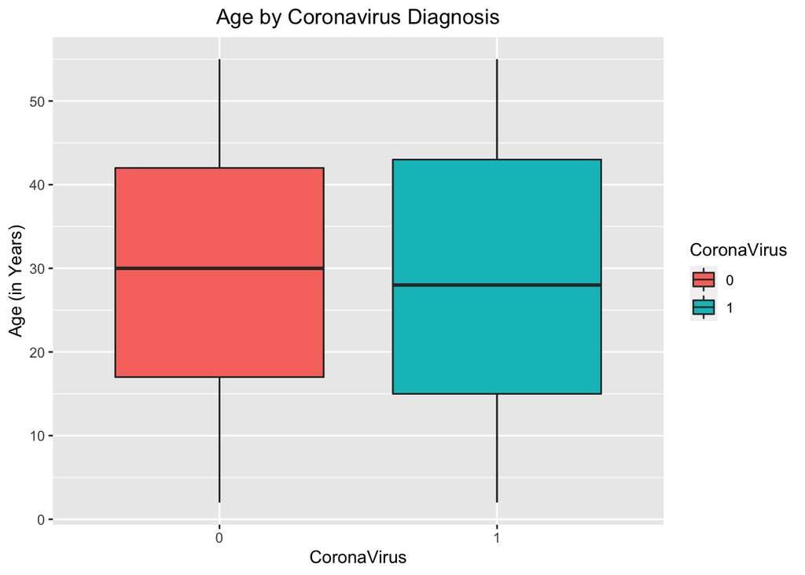

```r
# Factor the variables
factor_df <-merged_id_df

factor_df$CoronaVirus <- as.factor(factor_df$CoronaVirus)

# Boxplot
pl <- ggplot(factor_df, aes(x = CoronaVirus, y = Age)) + geom_boxplot()

pl + geom_boxplot(aes(fill=CoronaVirus)) +
  ylab("Age (in Years)") + ggtitle("Age by Coronavirus Diagnosis") + theme(plot.title = element_text(hjust = 0.5))
```

## Reference

COVID-19 and Your Health.(2020, February 11).Centers for Disease Control and Prevention. https://www.cdc.gov/coronavirus/2019-ncov/transmission/index.html

Coronavirus Cases.(n.d.).Retrieved from https://www.worldometers.info/coronavirus/